# Graphing in R: 101

# Customizing other elements of `ggplot` graphs

As in `base R`, we can customize the color of our plot, the points in it, the lines it generates and so on. In `ggplot` these are all aesthetic representations of the data. So most of this can be done inside of the call to `aes`. An advantage of doing so, is that we have more flexibility than we do in `base R` to change how each individual data point is represented in our graph.

For example, let’s change the color of each point in the above graph, so that it’s shade will be tweaked, continuously, as the price increases.

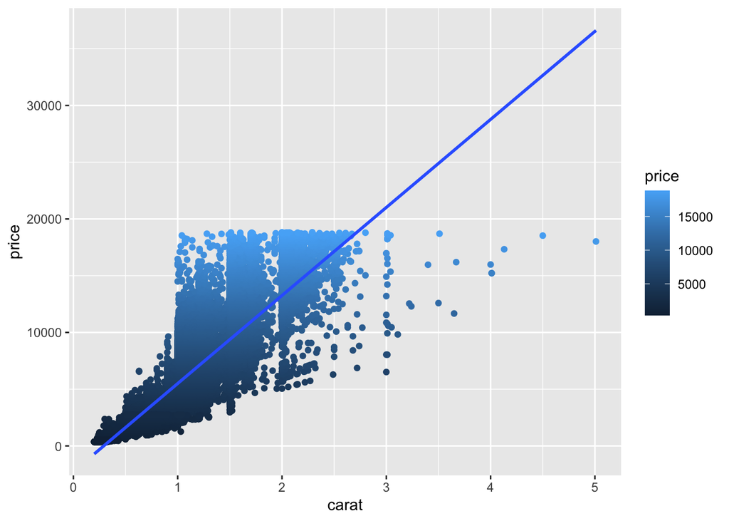

```r
ggplot(data = diamonds, mapping = aes(x = carat, y = price)) +
  geom_point(aes(color = price)) +
  geom_smooth(method = 'lm', formula = 'y ~ x')
```

We can also change the palette, so that the maximum price is mapped to a different hue (and likewise for the minimum). This is a reiteration of the concept that our data are at all times merely being mapped into different scales and aesthetic systems.

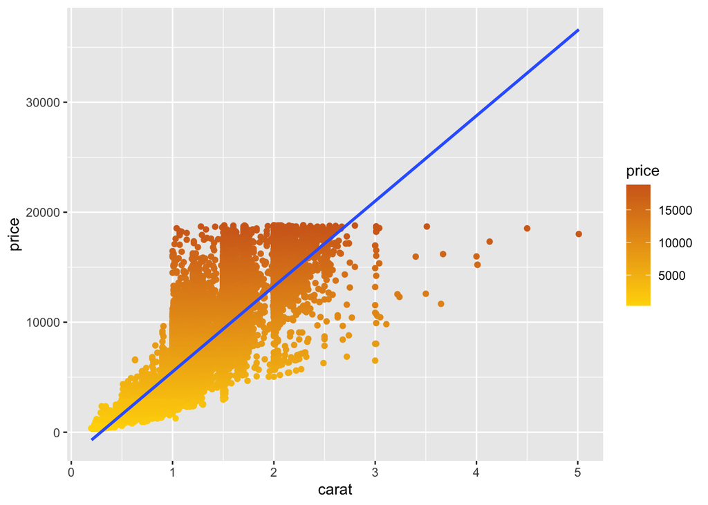

```r
ggplot(data = diamonds, mapping = aes(x = carat, y = price)) +
  geom_point(aes(color = price)) +
  geom_smooth(method = 'lm', formula = 'y ~ x') +
  scale_color_gradient(low = 'gold', high = 'chocolate')
```

# Further customization.

For each `geom_` function, a known set of parameters exist. For example, the first two arguments supplied to `geom_point` are the x and y coordinates, because no matter what coordinate system we are project the data into, a point will be comprised of only two coordinates. For other “geoms”, such as `geom_contour`, we need a $z$ variable as well, for example.  
Below, we’ll take a look at the parameters that can be passed to `geom_point`

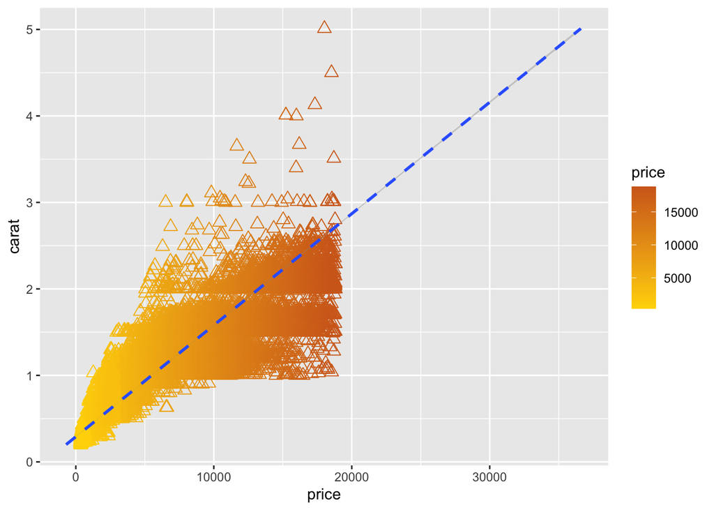

```r
ggplot(data = diamonds, mapping = aes(x = carat, y = price)) +
  geom_point(
    # again, mapping the price variable to the color of the points:
    aes(color = price),
    # the next two aesthetics are not 'mapped', because they are not coming from the data:
    shape = 24, # exactly the same as "pch" in base R
    size = 3 # the size of the point
  ) +
  geom_smooth(
    method = 'lm', formula = 'y ~ x',
    linetype = 2 # works the same as lty in base R
  ) +
  scale_color_gradient(low = 'gold', high = 'chocolate') +
  coord_flip() # Here, we flip the location of the x and y axes
```

Using a `facet`, we can create a seperate graph for different levels of a grouping variable

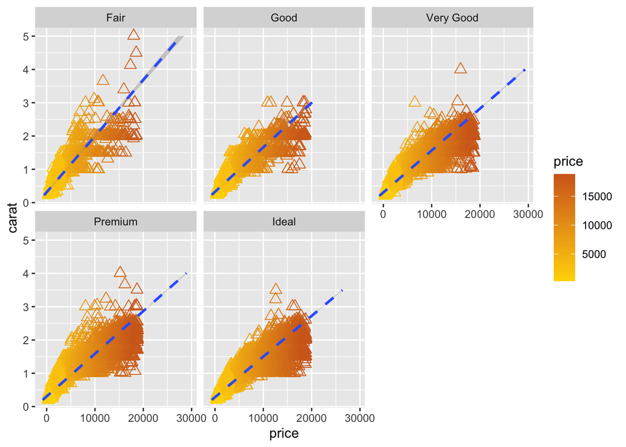

```r
ggplot(data = diamonds, mapping = aes(x = carat, y = price)) +
  geom_point(
    # again, mapping the price variable to the color of the points:
    aes(color = price),
    # the next two aesthetics are not 'mapped', because they are not coming from the data:
    shape = 24, # exactly the same as "pch" in base R
    size = 3 # the size of the point
  ) +
  geom_smooth(
    method = 'lm', formula = 'y ~ x',
    linetype = 2 # works the same as lty in base R
  ) +
  scale_color_gradient(low = 'gold', high = 'chocolate') +
  coord_flip() + # Here, we flip the location of the x and y axes
  facet_wrap(~cut) # similar to the formula syntax
```

We can also change the type of regression line if we think the relationship is non-linear. In addition, the layer of the graph that constitutes the coordinate plane can be modified to change the color, scale, etc. We’ll change the color and the drawing of the grid lines here as well. These changes are mostly conducted using `theme()` functions.

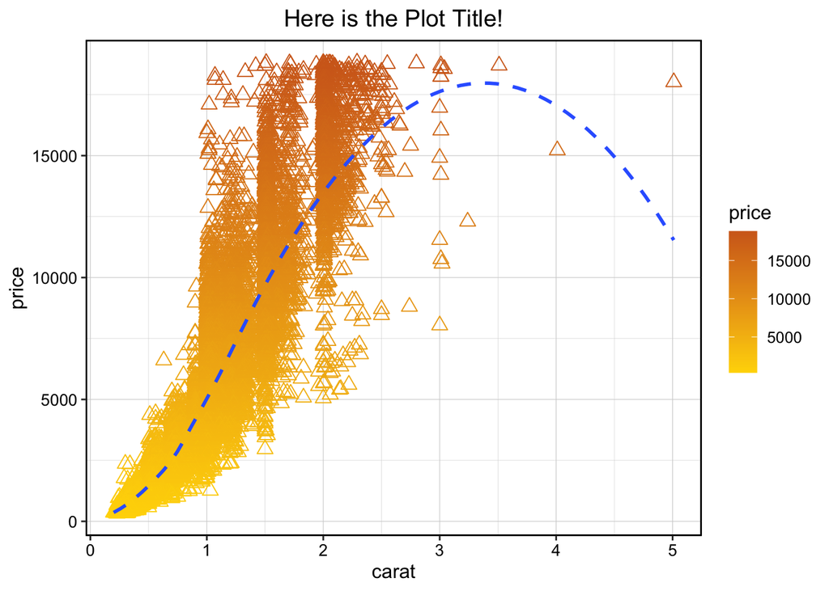

```r
library(tidyverse)
ggplot(data = sample_frac(diamonds, size = .4), # just plot 40% of the data to reduce computational cost
       mapping = aes(x = carat, y = price)) +
  geom_point(
    # again, mapping the price variable to the color of the points:
    aes(color = price),
    # the next two aesthetics are not 'mapped', because they are not coming from the data:
    shape = 24, # exactly the same as "pch" in base R
    size = 3 # the size of the point
  ) +
  geom_smooth(
    method = 'loess', # fit a non-parametric smoothing curve
    formula = 'y ~ x',
    se = FALSE, # let's not plot the standard error band to reduce computing cost
    linetype = 2 # works the same as "lty" in base R
  ) +
  scale_color_gradient(low = 'gold', high = 'chocolate') +
  # Now to change some of the elements of the coordinate plane
  theme(plot.title = element_text(hjust = .5), text = element_text(size = 12)) +
  theme(panel.border = element_rect(color = 'black', fill = NA, size = .9)) +
  theme(panel.background = element_rect(color = 'black', fill = 'white')) +
  theme(panel.grid = element_line(color = 'lightgrey', size = .2)) +
  theme(plot.background = element_rect(fill = 'white')) +
  theme(axis.text = element_text(size = 10, color = 'black')) +
  # We can add a title too
  ggtitle(label = 'Here is the Plot Title!')
```